# Marketing analytics with greybox

Ivan Svetunkov

2020-12-01

One of the reasons why I have started the `greybox` package is to use it for marketing research and marketing analytics. The common problem that I face, when working with these courses is analysing the data measured in different scales. While R handles numeric scales natively, the work with categorical is not satisfactory. Yes, I know that there are packages that implement some of the functions, but I wanted to have them in one place without the need to install a lot of packages and satisfy the dependencies. After all, what’s the point in installing a package for Cramer’s V, when it can be calculated with two lines of code? So, here’s a brief explanation of the functions for marketing analytics.

I will use `mtcars` dataset for the examples, but we will transform some of the variables into factors:

```r
mtcarsData <- as.data.frame(mtcars)
mtcarsData$vs <- factor(mtcarsData$vs, levels=c(0,1), labels=c("v","s"))
mtcarsData$am <- factor(mtcarsData$am, levels=c(0,1), labels=c("a","m"))
```

# Analysing the relation between the two variables in categorical scales

## Cramer’s V

Cramer’s V measures the relation between two variables in categorical scale. It is implemented in the `cramer()` function. It returns the value in a range of 0 to 1 (1 - when the two categorical variables are linearly associated with each other, 0 - otherwise), Chi-Squared statistics from the `chisq.test()`, the respective p-value and the number of degrees of freedom. The tested hypothesis in this case is formulated as:

$H_0: V=0$ (the variables don’t have association);

$H_1: V\neq 0$ (there is an association between the variables).

Here’s what we get when trying to find the association between the engine and transmission in the `mtcars` data:

```r
cramer(mtcarsData$vs, mtcarsData$am)
```

```
#> Cramer's V: 0.1042
#> Chi^2 statistics = 0.3475, df: 1, p-value: 0.5555
```

Judging by this output, the association between these two variables is very low (close to zero) and is not statistically significant.

Cramer’s V can also be used for the data in numerical scales. In general, this might be not the most suitable solution, but this might be useful when you have a small number of values in the data. For example, the variable `gear` in `mtcars` is numerical, but it has only three options (3, 4 and 5). Here’s what Cramer’s V tells us in the case of `gear` and `am`:

```r
cramer(mtcarsData$am, mtcarsData$gear)
```

```
#> Cramer's V: 0.809
#> Chi^2 statistics = 20.9447, df: 2, p-value: 0
```

As we see, the value is high in this case (0.809), and the null hypothesis is rejected on 5%. So we can conclude that there is a relation between the two variables. This does not mean that one variable causes the other one, but they both might be driven by something else (do more expensive cars have less gears but the automatic transmission?).

## Plotting categorical variables

While R allows plotting two categorical variables against each other, the plot is hard to read and is not very helpful (in my opinion):

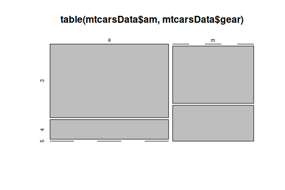

```r
plot(table(mtcarsData$am,mtcarsData$gear))
```

So I have created a function that produces a heat map for two categorical variables. It is called `tableplot()`:

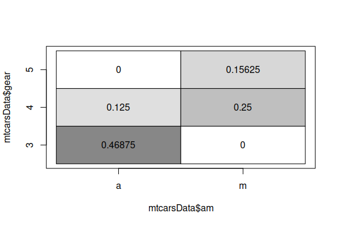

```r
tableplot(mtcarsData$am,mtcarsData$gear)
```

It is based on `table()` function and uses the frequencies inside the table for the colours:

```r
table(mtcarsData$am,mtcarsData$gear) / length(mtcarsData$am)
```

```
#>
#>           3       4       5
#>   a 0.46875 0.12500 0.00000
#>   m 0.00000 0.25000 0.15625
```

# Association between the categorical and numerical variables

While Cramer’s V can also be used for the measurement of association between the variables in different scales, there are better instruments. For example, some analysts recommend using [intraclass correlation coefficient](https://en.wikipedia.org/wiki/Intraclass_correlation) when measuring the relation between the numerical and categorical variables. But there is a simpler option, which involves calculating the coefficient of multiple correlation between the variables. This is implemented in `mcor()` function of `greybox`. The `y` variable should be numerical, while `x` can be of any type. What the function then does is expands all the factors and runs a regression via `.lm.fit()` function, returning the square root of the coefficient of determination. If the variables are linearly related, then the returned value will be close to one. Otherwise it will be closet to zero. The function also returns the F statistics from the regression, the associated p-value and the number of degrees of freedom (the hypothesis is formulated similarly to `cramer()` function).

Here’s how it works:

```r
mcor(mtcarsData$am,mtcarsData$mpg)
```

```
#> Multiple correlations value: 0.5998
#> F-statistics = 16.8603, df: 1, df resid: 30, p-value: 3e-04
```

In this example, the simple linear regression of `mpg` from the set of dummies is constructed, and we can conclude that there is a linear relation between the variables, and that this relation is statistically significant.

# Association between several variables

## Measures of association

When you deal with datasets (i.e. data frames or matrices), then you can use `cor()` function in order to calculate the correlation coefficients between the variables in the data. But when you have a mixture of numerical and categorical variables, the situation becomes more difficult, as the correlation does not make sense for the latter. This motivated me to create a function that uses either `cor()`, or `cramer()`, or `mcor()` functions depending on the types of data (see discussions of `cramer()` and `mcor()` above). The function is called `association()` or `assoc()` and returns three matrices: the values of the measures of association, their p-values and the types of the functions used between the variables. Here’s an example:

```r
assocValues <- assoc(mtcarsData)
print(assocValues,digits=2)
```

```
#> Associations:
#> values:
#>        mpg  cyl  disp    hp  drat    wt  qsec   vs   am gear carb
#> mpg   1.00 0.86 -0.85 -0.78  0.68 -0.87  0.42 0.66 0.60 0.66 0.67
#> cyl   0.86 1.00  0.92  0.84  0.70  0.78  0.59 0.82 0.52 0.53 0.62
#> disp -0.85 0.92  1.00  0.79 -0.71  0.89 -0.43 0.71 0.59 0.77 0.56
#> hp   -0.78 0.84  0.79  1.00 -0.45  0.66 -0.71 0.72 0.24 0.66 0.79
#> drat  0.68 0.70 -0.71 -0.45  1.00 -0.71  0.09 0.44 0.71 0.83 0.33
#> wt   -0.87 0.78  0.89  0.66 -0.71  1.00 -0.17 0.55 0.69 0.66 0.61
#> qsec  0.42 0.59 -0.43 -0.71  0.09 -0.17  1.00 0.74 0.23 0.63 0.67
#> vs    0.66 0.82  0.71  0.72  0.44  0.55  0.74 1.00 0.10 0.62 0.69
#> am    0.60 0.52  0.59  0.24  0.71  0.69  0.23 0.10 1.00 0.81 0.44
#> gear  0.66 0.53  0.77  0.66  0.83  0.66  0.63 0.62 0.81 1.00 0.51
#> carb  0.67 0.62  0.56  0.79  0.33  0.61  0.67 0.69 0.44 0.51 1.00
#>
#> p-values:
#>       mpg  cyl disp   hp drat   wt qsec   vs   am gear carb
#> mpg  0.00 0.00 0.00 0.00 0.00 0.00 0.02 0.00 0.00 0.00 0.01
#> cyl  0.00 0.00 0.00 0.00 0.00 0.00 0.00 0.00 0.01 0.00 0.01
#> disp 0.00 0.00 0.00 0.00 0.00 0.00 0.01 0.00 0.00 0.00 0.07
#> hp   0.00 0.00 0.00 0.00 0.01 0.00 0.00 0.00 0.18 0.00 0.00
#> drat 0.00 0.00 0.00 0.01 0.00 0.00 0.62 0.01 0.00 0.00 0.66
#> wt   0.00 0.00 0.00 0.00 0.00 0.00 0.34 0.00 0.00 0.00 0.02
#> qsec 0.02 0.00 0.01 0.00 0.62 0.34 0.00 0.00 0.21 0.00 0.01
#> vs   0.00 0.00 0.00 0.00 0.01 0.00 0.00 0.00 0.56 0.00 0.01
#> am   0.00 0.01 0.00 0.18 0.00 0.00 0.21 0.56 0.00 0.00 0.28
#> gear 0.00 0.00 0.00 0.00 0.00 0.00 0.00 0.00 0.00 0.00 0.09
#> carb 0.01 0.01 0.07 0.00 0.66 0.02 0.01 0.01 0.28 0.09 0.00
#>
#> types:
#>      mpg       cyl      disp      hp        drat      wt        qsec
#> mpg  "none"    "mcor"   "pearson" "pearson" "pearson" "pearson" "pearson"
#> cyl  "mcor"    "none"   "mcor"    "mcor"    "mcor"    "mcor"    "mcor"
#> disp "pearson" "mcor"   "none"    "pearson" "pearson" "pearson" "pearson"
#> hp   "pearson" "mcor"   "pearson" "none"    "pearson" "pearson" "pearson"
#> drat "pearson" "mcor"   "pearson" "pearson" "none"    "pearson" "pearson"
#> wt   "pearson" "mcor"   "pearson" "pearson" "pearson" "none"    "pearson"
#> qsec "pearson" "mcor"   "pearson" "pearson" "pearson" "pearson" "none"
#> vs   "mcor"    "cramer" "mcor"    "mcor"    "mcor"    "mcor"    "mcor"
#> am   "mcor"    "cramer" "mcor"    "mcor"    "mcor"    "mcor"    "mcor"
#> gear "mcor"    "cramer" "mcor"    "mcor"    "mcor"    "mcor"    "mcor"
#> carb "mcor"    "cramer" "mcor"    "mcor"    "mcor"    "mcor"    "mcor"
#>      vs       am       gear     carb
#> mpg  "mcor"   "mcor"   "mcor"   "mcor"
#> cyl  "cramer" "cramer" "cramer" "cramer"
#> disp "mcor"   "mcor"   "mcor"   "mcor"
#> hp   "mcor"   "mcor"   "mcor"   "mcor"
#> drat "mcor"   "mcor"   "mcor"   "mcor"
#> wt   "mcor"   "mcor"   "mcor"   "mcor"
#> qsec "mcor"   "mcor"   "mcor"   "mcor"
#> vs   "none"   "cramer" "cramer" "cramer"
#> am   "cramer" "none"   "cramer" "cramer"
#> gear "cramer" "cramer" "none"   "cramer"
#> carb "cramer" "cramer" "cramer" "none"
```

One thing to note is that the function considers numerical variables as categorical, when they only have up to 10 unique values. This is useful in case of number of gears in the dataset.

In addition, there is a parameter `method` in the function, which forces it to apply a specific measure of association to all the variables. This can be either Pearson / Spearman / Kendall correlation (using `cor.test()` function) or Cramer’s V (`cramer()` function from `greybox`). Note however, that it might not produce anything meaningful, when you apply the function with some methods to variables in categorical scales (e.g. correlation does not make sense between price and colour).

## Partial correlations

Sometimes you might want to get an idea of the pure correlation between two variables, `x` and `y` - the one that is free of the potential influence of other variables, for example, some variable `z`. This is called “partial correlation”. It is based on the two regression models: y = b0 + b1 z + e and x = a0 + a1 z + u - and then on the calculation of the Pearson’s correlations between the residuals of models, `cor(e,u)`. This is what the function `pcor()` does, using all the provided variables for `z`. It returns a matrix of partial correlations and a matrix of the respective p-values from the `cor.test()`:

```r
pcorValues <- pcor(mtcars)
print(pcorValues,digits=2)
```

```
#> Partial correlations using pearson method:
#> values:
#>        mpg   cyl  disp    hp  drat    wt  qsec    vs    am  gear  carb
#> mpg   1.00  0.10  0.16 -0.20  0.18 -0.40  0.48  0.02  0.29  0.16 -0.07
#> cyl   0.10  1.00  0.35  0.32  0.00 -0.17  0.40 -0.52 -0.17 -0.13  0.21
#> disp  0.16  0.35  1.00  0.54  0.10  0.76 -0.45 -0.10 -0.07  0.06 -0.66
#> hp   -0.20  0.32  0.54  1.00 -0.03 -0.30  0.02  0.27  0.12  0.16  0.50
#> drat  0.18  0.00  0.10 -0.03  1.00 -0.13  0.35 -0.01  0.22  0.26  0.18
#> wt   -0.40 -0.17  0.76 -0.30 -0.13  1.00  0.75 -0.06  0.01 -0.15  0.62
#> qsec  0.48  0.40 -0.45  0.02  0.35  0.75  1.00  0.40 -0.27  0.26 -0.46
#> vs    0.02 -0.52 -0.10  0.27 -0.01 -0.06  0.40  1.00 -0.23  0.00 -0.08
#> am    0.29 -0.17 -0.07  0.12  0.22  0.01 -0.27 -0.23  1.00  0.38 -0.07
#> gear  0.16 -0.13  0.06  0.16  0.26 -0.15  0.26  0.00  0.38  1.00  0.42
#> carb -0.07  0.21 -0.66  0.50  0.18  0.62 -0.46 -0.08 -0.07  0.42  1.00
#>
#> p-values:
#>       mpg  cyl disp   hp drat   wt qsec   vs   am gear carb
#> mpg  0.00 0.60 0.38 0.27 0.33 0.02 0.01 0.92 0.10 0.37 0.71
#> cyl  0.60 0.00 0.05 0.07 0.98 0.34 0.02 0.00 0.36 0.47 0.25
#> disp 0.38 0.05 0.00 0.00 0.57 0.00 0.01 0.57 0.71 0.72 0.00
#> hp   0.27 0.07 0.00 0.00 0.88 0.09 0.92 0.14 0.52 0.39 0.00
#> drat 0.33 0.98 0.57 0.88 0.00 0.46 0.05 0.94 0.23 0.15 0.32
#> wt   0.02 0.34 0.00 0.09 0.46 0.00 0.00 0.73 0.94 0.41 0.00
#> qsec 0.01 0.02 0.01 0.92 0.05 0.00 0.00 0.02 0.13 0.14 0.01
#> vs   0.92 0.00 0.57 0.14 0.94 0.73 0.02 0.00 0.20 0.99 0.66
#> am   0.10 0.36 0.71 0.52 0.23 0.94 0.13 0.20 0.00 0.03 0.71
#> gear 0.37 0.47 0.72 0.39 0.15 0.41 0.14 0.99 0.03 0.00 0.02
#> carb 0.71 0.25 0.00 0.00 0.32 0.00 0.01 0.66 0.71 0.02 0.00
```

These values might be useful on the stages of the variables selection.

## Plots of association between several variables

Similarly to the problem with `cor()`, scatterplot matrix (produced using `plot()`) is not meaningful in case of a mixture of variables:

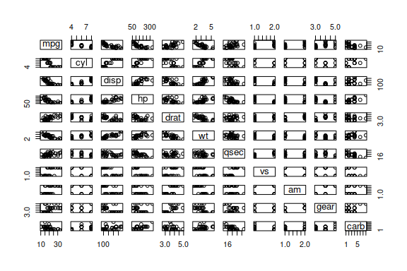

```r
plot(mtcarsData)
```

It makes sense to use scatterplot in case of numeric variables, `tableplot()` in case of categorical and `boxplot()` in case of a mixture. So, there is the function `spread()` in `greybox` that creates something more meaningful. It uses the same algorithm as `assoc()` function, but produces plots instead of calculating measures of association. So, `gear` will be considered as categorical and the function will produce either `boxplot()` or `tableplot()`, when plotting it against other variables.

Here’s an example:

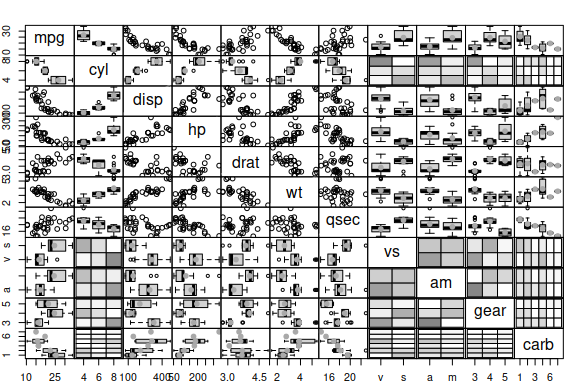

```r
spread(mtcarsData)
```

This plot demonstrates, for example, that the number of carburetors influences fuel consumption (something that we could not have spotted in the case of `plot()`). Notice also, that the number of gears influences the fuel consumption in a non-linear relation as well. So constructing the model with dummy variables for the number of gears might be a reasonable thing to do.

The function also has the parameter `log`, which will transform all the numerical variables using logarithms, which is handy, when you suspect the non-linear relation between the variables. Finally, there is a parameter `histogram`, which will plot either histograms, or barplots on the diagonal.

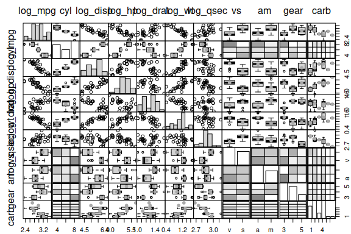

```r
spread(mtcarsData, histograms=TRUE, log=TRUE)
```

The plot demonstrates that the `disp` has a strong non-linear relation with `mpg`, and, similarly, `drat` and `hp` also influence `mpg` in a non-linear fashion.

# Regression diagnostics

One of the problems of linear regression that can be diagnosed prior to the model construction is multicollinearity. The conventional way of doing this diagnostics is via calculating the variance inflation factor (VIF) after constructing the model. However, VIF is not easy to interpret, because it lies in $(1, \infty)$. Coefficients of determination from the linear regression models of explanatory variables are easier to interpret and work with. If such a coefficient is equal to one, then there are some perfectly correlated explanatory variables in the dataset. If it is equal to zero, then they are not linearly related.

There is a function `determination()` or `determ()` in `greybox` that returns the set of coefficients of determination for the explanatory variables. The good thing is that this can be done before constructing any model. In our example, the first column, `mpg` is the response variable, so we can diagnose the multicollinearity the following way:

```r
determination(mtcarsData[,-1])
```

```
#>       cyl      disp        hp      drat        wt      qsec        vs        am
#> 0.9349544 0.9537470 0.8982917 0.7036703 0.9340582 0.8671619 0.8017720 0.7924392
#>      gear      carb
#> 0.8133441 0.8735577
```

As we can see from the output above, `disp` is the most linearly related with the variables, so including it in the model might cause the multicollinearity, which will make the estimates of parameters less efficient.